# Risk Factor Analysis

## Outcome Variable

**Outcome Variable:** y_rate_len

## Predictor Variables

**Intervention Variable:** exclfeed6

**Adjustment Set:**

- arm
- sex
- brthmon
- W_mage
- meducyrs
- feducyrs
- hhwealth_quart
- hfoodsec
- W_mhtcm
- W_mwtkg
- W_mbmi
- vagbrth
- W_birthwt
- W_birthlen
- W_nrooms
- month
- W_parity
- impfloor
- impsan
- safeh20
- delta_W_mage
- delta_meducyrs
- delta_feducyrs
- delta_hhwealth_quart
- delta_hfoodsec
- delta_W_mhtcm
- delta_W_mwtkg
- delta_W_mbmi
- delta_vagbrth
- delta_W_birthwt
- delta_W_birthlen
- delta_W_nrooms
- delta_month
- delta_W_parity
- delta_impfloor
- delta_impsan
- delta_safeh20

## Stratifying Variables

The analysis was stratified on these variable(s):

- agecat
- studyid
- country

## Data Summary

| agecat | studyid | country | exclfeed6 | n_cell | n |
| --- | --- | --- | --- | --- | --- |
| 0-3 months | CMC-V-BCS-2002 | INDIA | 1 | 6 | 6 |
| 0-3 months | CMC-V-BCS-2002 | INDIA | 0 | 0 | 6 |
| 0-3 months | EE | PAKISTAN | 1 | 33 | 37 |
| 0-3 months | EE | PAKISTAN | 0 | 4 | 37 |
| 0-3 months | GMS-Nepal | NEPAL | 1 | 368 | 501 |
| 0-3 months | GMS-Nepal | NEPAL | 0 | 133 | 501 |
| 0-3 months | IRC | INDIA | 1 | 0 | 14 |
| 0-3 months | IRC | INDIA | 0 | 14 | 14 |
| 0-3 months | JiVitA-3 | BANGLADESH | 1 | 9246 | 11961 |
| 0-3 months | JiVitA-3 | BANGLADESH | 0 | 2715 | 11961 |
| 0-3 months | JiVitA-4 | BANGLADESH | 1 | 1509 | 1805 |
| 0-3 months | JiVitA-4 | BANGLADESH | 0 | 296 | 1805 |
| 0-3 months | Keneba | GAMBIA | 1 | 391 | 1207 |
| 0-3 months | Keneba | GAMBIA | 0 | 816 | 1207 |
| 0-3 months | MAL-ED | BANGLADESH | 1 | 33 | 227 |
| 0-3 months | MAL-ED | BANGLADESH | 0 | 194 | 227 |
| 0-3 months | MAL-ED | BRAZIL | 1 | 7 | 163 |
| 0-3 months | MAL-ED | BRAZIL | 0 | 156 | 163 |
| 0-3 months | MAL-ED | INDIA | 1 | 1 | 167 |
| 0-3 months | MAL-ED | INDIA | 0 | 166 | 167 |
| 0-3 months | MAL-ED | NEPAL | 1 | 4 | 145 |
| 0-3 months | MAL-ED | NEPAL | 0 | 141 | 145 |
| 0-3 months | MAL-ED | PERU | 1 | 3 | 254 |
| 0-3 months | MAL-ED | PERU | 0 | 251 | 254 |
| 0-3 months | MAL-ED | SOUTH AFRICA | 1 | 0 | 186 |
| 0-3 months | MAL-ED | SOUTH AFRICA | 0 | 186 | 186 |
| 0-3 months | MAL-ED | TANZANIA, UNITED REPUBLIC OF | 1 | 0 | 211 |
| 0-3 months | MAL-ED | TANZANIA, UNITED REPUBLIC OF | 0 | 211 | 211 |
| 0-3 months | PROVIDE | BANGLADESH | 1 | 159 | 640 |
| 0-3 months | PROVIDE | BANGLADESH | 0 | 481 | 640 |

[output cut: 226 more lines]

The following strata were considered:

- agecat: 0-3 months, studyid: CMC-V-BCS-2002, country: INDIA
- agecat: 0-3 months, studyid: EE, country: PAKISTAN
- agecat: 0-3 months, studyid: GMS-Nepal, country: NEPAL
- agecat: 0-3 months, studyid: IRC, country: INDIA
- agecat: 0-3 months, studyid: JiVitA-3, country: BANGLADESH
- agecat: 0-3 months, studyid: JiVitA-4, country: BANGLADESH
- agecat: 0-3 months, studyid: Keneba, country: GAMBIA
- agecat: 0-3 months, studyid: MAL-ED, country: BANGLADESH
- agecat: 0-3 months, studyid: MAL-ED, country: BRAZIL
- agecat: 0-3 months, studyid: MAL-ED, country: INDIA
- agecat: 0-3 months, studyid: MAL-ED, country: NEPAL
- agecat: 0-3 months, studyid: MAL-ED, country: PERU
- agecat: 0-3 months, studyid: MAL-ED, country: SOUTH AFRICA
- agecat: 0-3 months, studyid: MAL-ED, country: TANZANIA, UNITED REPUBLIC OF
- agecat: 0-3 months, studyid: PROVIDE, country: BANGLADESH
- agecat: 0-3 months, studyid: SAS-CompFeed, country: INDIA
- agecat: 12-15 months, studyid: CMC-V-BCS-2002, country: INDIA
- agecat: 12-15 months, studyid: EE, country: PAKISTAN
- agecat: 12-15 months, studyid: GMS-Nepal, country: NEPAL
- agecat: 12-15 months, studyid: IRC, country: INDIA
- agecat: 12-15 months, studyid: JiVitA-4, country: BANGLADESH
- agecat: 12-15 months, studyid: Keneba, country: GAMBIA
- agecat: 12-15 months, studyid: LCNI-5, country: MALAWI
- agecat: 12-15 months, studyid: MAL-ED, country: BANGLADESH
- agecat: 12-15 months, studyid: MAL-ED, country: BRAZIL
- agecat: 12-15 months, studyid: MAL-ED, country: INDIA
- agecat: 12-15 months, studyid: MAL-ED, country: NEPAL
- agecat: 12-15 months, studyid: MAL-ED, country: PERU
- agecat: 12-15 months, studyid: MAL-ED, country: SOUTH AFRICA
- agecat: 12-15 months, studyid: MAL-ED, country: TANZANIA, UNITED REPUBLIC OF
- agecat: 12-15 months, studyid: PROVIDE, country: BANGLADESH
- agecat: 12-15 months, studyid: SAS-CompFeed, country: INDIA
- agecat: 12-15 months, studyid: SAS-FoodSuppl, country: INDIA
- agecat: 15-18 months, studyid: CMC-V-BCS-2002, country: INDIA
- agecat: 15-18 months, studyid: EE, country: PAKISTAN
- agecat: 15-18 months, studyid: GMS-Nepal, country: NEPAL
- agecat: 15-18 months, studyid: IRC, country: INDIA
- agecat: 15-18 months, studyid: JiVitA-4, country: BANGLADESH
- agecat: 15-18 months, studyid: Keneba, country: GAMBIA
- agecat: 15-18 months, studyid: LCNI-5, country: MALAWI
- agecat: 15-18 months, studyid: MAL-ED, country: BANGLADESH
- agecat: 15-18 months, studyid: MAL-ED, country: BRAZIL
- agecat: 15-18 months, studyid: MAL-ED, country: INDIA
- agecat: 15-18 months, studyid: MAL-ED, country: NEPAL
- agecat: 15-18 months, studyid: MAL-ED, country: PERU
- agecat: 15-18 months, studyid: MAL-ED, country: SOUTH AFRICA
- agecat: 15-18 months, studyid: MAL-ED, country: TANZANIA, UNITED REPUBLIC OF
- agecat: 15-18 months, studyid: PROVIDE, country: BANGLADESH
- agecat: 15-18 months, studyid: SAS-CompFeed, country: INDIA
- agecat: 15-18 months, studyid: SAS-FoodSuppl, country: INDIA
- agecat: 18-21 months, studyid: CMC-V-BCS-2002, country: INDIA
- agecat: 18-21 months, studyid: EE, country: PAKISTAN
- agecat: 18-21 months, studyid: GMS-Nepal, country: NEPAL
- agecat: 18-21 months, studyid: IRC, country: INDIA
- agecat: 18-21 months, studyid: Keneba, country: GAMBIA
- agecat: 18-21 months, studyid: LCNI-5, country: MALAWI
- agecat: 18-21 months, studyid: MAL-ED, country: BANGLADESH
- agecat: 18-21 months, studyid: MAL-ED, country: BRAZIL
- agecat: 18-21 months, studyid: MAL-ED, country: INDIA
- agecat: 18-21 months, studyid: MAL-ED, country: NEPAL
- agecat: 18-21 months, studyid: MAL-ED, country: PERU
- agecat: 18-21 months, studyid: MAL-ED, country: SOUTH AFRICA
- agecat: 18-21 months, studyid: MAL-ED, country: TANZANIA, UNITED REPUBLIC OF
- agecat: 18-21 months, studyid: PROVIDE, country: BANGLADESH
- agecat: 21-24 months, studyid: CMC-V-BCS-2002, country: INDIA
- agecat: 21-24 months, studyid: EE, country: PAKISTAN
- agecat: 21-24 months, studyid: GMS-Nepal, country: NEPAL
- agecat: 21-24 months, studyid: IRC, country: INDIA
- agecat: 21-24 months, studyid: Keneba, country: GAMBIA
- agecat: 21-24 months, studyid: LCNI-5, country: MALAWI
- agecat: 21-24 months, studyid: MAL-ED, country: BANGLADESH
- agecat: 21-24 months, studyid: MAL-ED, country: BRAZIL
- agecat: 21-24 months, studyid: MAL-ED, country: INDIA
- agecat: 21-24 months, studyid: MAL-ED, country: NEPAL
- agecat: 21-24 months, studyid: MAL-ED, country: PERU
- agecat: 21-24 months, studyid: MAL-ED, country: SOUTH AFRICA
- agecat: 21-24 months, studyid: MAL-ED, country: TANZANIA, UNITED REPUBLIC OF
- agecat: 21-24 months, studyid: PROVIDE, country: BANGLADESH
- agecat: 3-6 months, studyid: CMC-V-BCS-2002, country: INDIA
- agecat: 3-6 months, studyid: EE, country: PAKISTAN
- agecat: 3-6 months, studyid: GMS-Nepal, country: NEPAL
- agecat: 3-6 months, studyid: IRC, country: INDIA
- agecat: 3-6 months, studyid: JiVitA-3, country: BANGLADESH
- agecat: 3-6 months, studyid: JiVitA-4, country: BANGLADESH
- agecat: 3-6 months, studyid: Keneba, country: GAMBIA
- agecat: 3-6 months, studyid: MAL-ED, country: BANGLADESH
- agecat: 3-6 months, studyid: MAL-ED, country: BRAZIL
- agecat: 3-6 months, studyid: MAL-ED, country: INDIA
- agecat: 3-6 months, studyid: MAL-ED, country: NEPAL
- agecat: 3-6 months, studyid: MAL-ED, country: PERU
- agecat: 3-6 months, studyid: MAL-ED, country: SOUTH AFRICA
- agecat: 3-6 months, studyid: MAL-ED, country: TANZANIA, UNITED REPUBLIC OF
- agecat: 3-6 months, studyid: PROVIDE, country: BANGLADESH
- agecat: 3-6 months, studyid: SAS-CompFeed, country: INDIA
- agecat: 6-9 months, studyid: CMC-V-BCS-2002, country: INDIA
- agecat: 6-9 months, studyid: EE, country: PAKISTAN
- agecat: 6-9 months, studyid: GMS-Nepal, country: NEPAL
- agecat: 6-9 months, studyid: IRC, country: INDIA
- agecat: 6-9 months, studyid: JiVitA-4, country: BANGLADESH
- agecat: 6-9 months, studyid: Keneba, country: GAMBIA
- agecat: 6-9 months, studyid: LCNI-5, country: MALAWI
- agecat: 6-9 months, studyid: MAL-ED, country: BANGLADESH
- agecat: 6-9 months, studyid: MAL-ED, country: BRAZIL
- agecat: 6-9 months, studyid: MAL-ED, country: INDIA
- agecat: 6-9 months, studyid: MAL-ED, country: NEPAL
- agecat: 6-9 months, studyid: MAL-ED, country: PERU
- agecat: 6-9 months, studyid: MAL-ED, country: SOUTH AFRICA
- agecat: 6-9 months, studyid: MAL-ED, country: TANZANIA, UNITED REPUBLIC OF
- agecat: 6-9 months, studyid: PROVIDE, country: BANGLADESH
- agecat: 6-9 months, studyid: SAS-CompFeed, country: INDIA
- agecat: 6-9 months, studyid: SAS-FoodSuppl, country: INDIA
- agecat: 9-12 months, studyid: CMC-V-BCS-2002, country: INDIA
- agecat: 9-12 months, studyid: EE, country: PAKISTAN
- agecat: 9-12 months, studyid: GMS-Nepal, country: NEPAL
- agecat: 9-12 months, studyid: IRC, country: INDIA
- agecat: 9-12 months, studyid: JiVitA-4, country: BANGLADESH
- agecat: 9-12 months, studyid: Keneba, country: GAMBIA
- agecat: 9-12 months, studyid: LCNI-5, country: MALAWI
- agecat: 9-12 months, studyid: MAL-ED, country: BANGLADESH
- agecat: 9-12 months, studyid: MAL-ED, country: BRAZIL
- agecat: 9-12 months, studyid: MAL-ED, country: INDIA
- agecat: 9-12 months, studyid: MAL-ED, country: NEPAL
- agecat: 9-12 months, studyid: MAL-ED, country: PERU
- agecat: 9-12 months, studyid: MAL-ED, country: SOUTH AFRICA
- agecat: 9-12 months, studyid: MAL-ED, country: TANZANIA, UNITED REPUBLIC OF
- agecat: 9-12 months, studyid: PROVIDE, country: BANGLADESH
- agecat: 9-12 months, studyid: SAS-CompFeed, country: INDIA
- agecat: 9-12 months, studyid: SAS-FoodSuppl, country: INDIA

### Dropped Strata

Some strata were dropped due to rare outcomes:

- agecat: 0-3 months, studyid: CMC-V-BCS-2002, country: INDIA
- agecat: 0-3 months, studyid: EE, country: PAKISTAN
- agecat: 0-3 months, studyid: IRC, country: INDIA
- agecat: 0-3 months, studyid: MAL-ED, country: INDIA
- agecat: 0-3 months, studyid: MAL-ED, country: NEPAL
- agecat: 0-3 months, studyid: MAL-ED, country: PERU
- agecat: 0-3 months, studyid: MAL-ED, country: SOUTH AFRICA
- agecat: 0-3 months, studyid: MAL-ED, country: TANZANIA, UNITED REPUBLIC OF
- agecat: 3-6 months, studyid: CMC-V-BCS-2002, country: INDIA
- agecat: 3-6 months, studyid: EE, country: PAKISTAN
- agecat: 3-6 months, studyid: IRC, country: INDIA
- agecat: 3-6 months, studyid: MAL-ED, country: INDIA
- agecat: 3-6 months, studyid: MAL-ED, country: NEPAL
- agecat: 3-6 months, studyid: MAL-ED, country: SOUTH AFRICA
- agecat: 3-6 months, studyid: MAL-ED, country: TANZANIA, UNITED REPUBLIC OF
- agecat: 6-9 months, studyid: CMC-V-BCS-2002, country: INDIA
- agecat: 6-9 months, studyid: IRC, country: INDIA
- agecat: 6-9 months, studyid: MAL-ED, country: INDIA
- agecat: 6-9 months, studyid: MAL-ED, country: SOUTH AFRICA
- agecat: 6-9 months, studyid: MAL-ED, country: TANZANIA, UNITED REPUBLIC OF
- agecat: 6-9 months, studyid: SAS-FoodSuppl, country: INDIA
- agecat: 9-12 months, studyid: CMC-V-BCS-2002, country: INDIA
- agecat: 9-12 months, studyid: IRC, country: INDIA
- agecat: 9-12 months, studyid: MAL-ED, country: INDIA
- agecat: 9-12 months, studyid: MAL-ED, country: NEPAL
- agecat: 9-12 months, studyid: MAL-ED, country: SOUTH AFRICA
- agecat: 9-12 months, studyid: MAL-ED, country: TANZANIA, UNITED REPUBLIC OF
- agecat: 9-12 months, studyid: SAS-FoodSuppl, country: INDIA
- agecat: 12-15 months, studyid: CMC-V-BCS-2002, country: INDIA
- agecat: 12-15 months, studyid: IRC, country: INDIA
- agecat: 12-15 months, studyid: LCNI-5, country: MALAWI
- agecat: 12-15 months, studyid: MAL-ED, country: INDIA
- agecat: 12-15 months, studyid: MAL-ED, country: NEPAL
- agecat: 12-15 months, studyid: MAL-ED, country: PERU
- agecat: 12-15 months, studyid: MAL-ED, country: SOUTH AFRICA
- agecat: 12-15 months, studyid: MAL-ED, country: TANZANIA, UNITED REPUBLIC OF
- agecat: 12-15 months, studyid: SAS-FoodSuppl, country: INDIA
- agecat: 15-18 months, studyid: CMC-V-BCS-2002, country: INDIA
- agecat: 15-18 months, studyid: IRC, country: INDIA
- agecat: 15-18 months, studyid: LCNI-5, country: MALAWI
- agecat: 15-18 months, studyid: MAL-ED, country: INDIA
- agecat: 15-18 months, studyid: MAL-ED, country: PERU
- agecat: 15-18 months, studyid: MAL-ED, country: SOUTH AFRICA
- agecat: 15-18 months, studyid: MAL-ED, country: TANZANIA, UNITED REPUBLIC OF
- agecat: 15-18 months, studyid: SAS-FoodSuppl, country: INDIA
- agecat: 18-21 months, studyid: CMC-V-BCS-2002, country: INDIA
- agecat: 18-21 months, studyid: IRC, country: INDIA
- agecat: 18-21 months, studyid: MAL-ED, country: INDIA
- agecat: 18-21 months, studyid: MAL-ED, country: PERU
- agecat: 18-21 months, studyid: MAL-ED, country: SOUTH AFRICA
- agecat: 18-21 months, studyid: MAL-ED, country: TANZANIA, UNITED REPUBLIC OF
- agecat: 21-24 months, studyid: CMC-V-BCS-2002, country: INDIA
- agecat: 21-24 months, studyid: EE, country: PAKISTAN
- agecat: 21-24 months, studyid: IRC, country: INDIA
- agecat: 21-24 months, studyid: MAL-ED, country: INDIA
- agecat: 21-24 months, studyid: MAL-ED, country: PERU
- agecat: 21-24 months, studyid: MAL-ED, country: SOUTH AFRICA
- agecat: 21-24 months, studyid: MAL-ED, country: TANZANIA, UNITED REPUBLIC OF

## Methods Detail

We’re interested in the causal parameters $E[Y_a]$ for all values of $a \in \mathcal{A}$. These parameters represent the mean outcome if, possibly contrary to fact, we intervened to set all units to have $A=a$. Under the randomization and positivity assumptions, these are identified by the statistical parameters $\psi_a=E_W[E_{Y|A,W}(Y|A=a,W)]$. In addition, we’re interested in the mean of $Y$, $E[Y]$ under no intervention (the observed mean). We will estimate these parameters by using SuperLearner to fit the relevant likelihood factors – $E_{Y|A,W}(Y|A=a,W)$ and $p(A=a|W)$, and then updating our likelihood fit using a joint TMLE.

For unadjusted analyses ($W=\{\}$), initial likelihoods were estimated using Lrnr_glm to estimate the simple $E(Y|A)$ and Lrnr_mean to estimate $p(A)$. For adjusted analyses, a small library containing Lrnr_glmnet, Lrnr_xgboost, and Lrnr_mean was used.

Having estimated these parameters, we will then use the delta method to estimate relative risks and attributable risks relative to a prespecified baseline level of $A$.

# Results Detail

## Results Plots

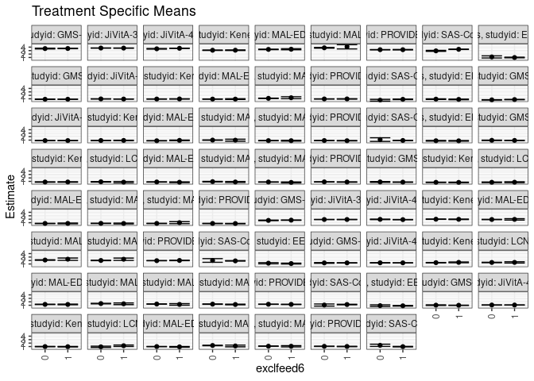

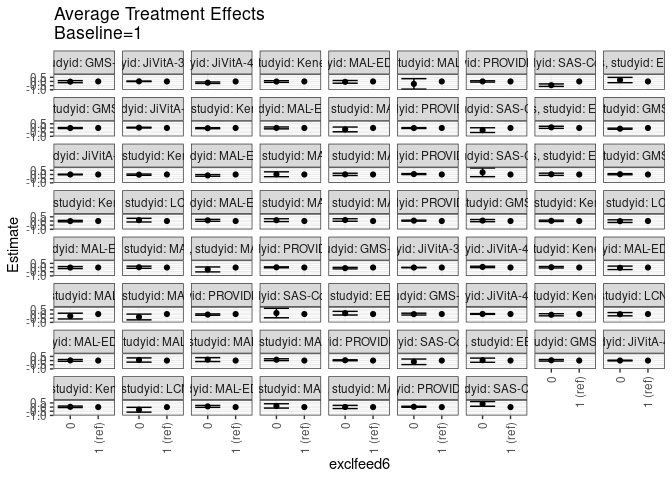

[figure not shown]

## Results Table

### Parameter: TSM

| agecat | studyid | country | intervention_level | baseline_level | estimate | ci_lower | ci_upper |
| --- | --- | --- | --- | --- | --- | --- | --- |
| 0-3 months | GMS-Nepal | NEPAL | 1 | NA | 3.6077919 | 3.5492692 | 3.6663146 |
| 0-3 months | GMS-Nepal | NEPAL | 0 | NA | 3.5809851 | 3.4730627 | 3.6889075 |
| 0-3 months | JiVitA-3 | BANGLADESH | 1 | NA | 3.7219926 | 3.7084510 | 3.7355341 |
| 0-3 months | JiVitA-3 | BANGLADESH | 0 | NA | 3.7360843 | 3.7129711 | 3.7591975 |
| 0-3 months | JiVitA-4 | BANGLADESH | 1 | NA | 3.6633061 | 3.6302845 | 3.6963277 |
| 0-3 months | JiVitA-4 | BANGLADESH | 0 | NA | 3.5135934 | 3.4296787 | 3.5975081 |
| 0-3 months | Keneba | GAMBIA | 1 | NA | 3.1122784 | 3.0294391 | 3.1951177 |
| 0-3 months | Keneba | GAMBIA | 0 | NA | 3.1018909 | 3.0424270 | 3.1613549 |
| 0-3 months | MAL-ED | BANGLADESH | 1 | NA | 3.3904236 | 3.2467319 | 3.5341152 |
| 0-3 months | MAL-ED | BANGLADESH | 0 | NA | 3.3442558 | 3.2687638 | 3.4197478 |
| 0-3 months | MAL-ED | BRAZIL | 1 | NA | 4.1001464 | 3.4832446 | 4.7170481 |
| 0-3 months | MAL-ED | BRAZIL | 0 | NA | 3.8064228 | 3.6939940 | 3.9188516 |
| 0-3 months | PROVIDE | BANGLADESH | 1 | NA | 3.2558977 | 3.1897171 | 3.3220783 |
| 0-3 months | PROVIDE | BANGLADESH | 0 | NA | 3.2588441 | 3.2148586 | 3.3028296 |
| 0-3 months | SAS-CompFeed | INDIA | 1 | NA | 3.3695026 | 3.3106339 | 3.4283713 |
| 0-3 months | SAS-CompFeed | INDIA | 0 | NA | 2.9240440 | 2.7812046 | 3.0668835 |
| 3-6 months | GMS-Nepal | NEPAL | 1 | NA | 1.7312382 | 1.6854289 | 1.7770475 |
| 3-6 months | GMS-Nepal | NEPAL | 0 | NA | 1.6567869 | 1.5775225 | 1.7360513 |
| 3-6 months | JiVitA-3 | BANGLADESH | 1 | NA | 1.9193317 | 1.9041370 | 1.9345264 |
| 3-6 months | JiVitA-3 | BANGLADESH | 0 | NA | 1.9181052 | 1.8938248 | 1.9423857 |
| 3-6 months | JiVitA-4 | BANGLADESH | 1 | NA | 1.8837059 | 1.8507880 | 1.9166238 |
| 3-6 months | JiVitA-4 | BANGLADESH | 0 | NA | 1.9551973 | 1.8798827 | 2.0305118 |
| 3-6 months | Keneba | GAMBIA | 1 | NA | 1.9688513 | 1.8973789 | 2.0403237 |
| 3-6 months | Keneba | GAMBIA | 0 | NA | 2.0040520 | 1.9551698 | 2.0529343 |
| 3-6 months | MAL-ED | BANGLADESH | 1 | NA | 1.9556557 | 1.7548895 | 2.1564218 |
| 3-6 months | MAL-ED | BANGLADESH | 0 | NA | 1.9199597 | 1.8674179 | 1.9725015 |
| 3-6 months | MAL-ED | BRAZIL | 1 | NA | 2.3786388 | 2.0413240 | 2.7159535 |
| 3-6 months | MAL-ED | BRAZIL | 0 | NA | 2.1342890 | 2.0522343 | 2.2163437 |
| 3-6 months | MAL-ED | PERU | 1 | NA | 2.3622909 | 2.0228505 | 2.7017313 |
| 3-6 months | MAL-ED | PERU | 0 | NA | 2.0104898 | 1.9431975 | 2.0777821 |

[output cut: 110 more lines]

### Parameter: E(Y)

| agecat | studyid | country | intervention_level | baseline_level | estimate | ci_lower | ci_upper |
| --- | --- | --- | --- | --- | --- | --- | --- |
| 0-3 months | GMS-Nepal | NEPAL | NA | NA | 3.5982617 | 3.5465367 | 3.6499867 |
| 0-3 months | JiVitA-3 | BANGLADESH | NA | NA | 3.7251075 | 3.7124931 | 3.7377219 |
| 0-3 months | JiVitA-4 | BANGLADESH | NA | NA | 3.6386843 | 3.6074983 | 3.6698703 |
| 0-3 months | Keneba | GAMBIA | NA | NA | 3.1044617 | 3.0557519 | 3.1531714 |
| 0-3 months | MAL-ED | BANGLADESH | NA | NA | 3.3482498 | 3.2804281 | 3.4160715 |
| 0-3 months | MAL-ED | BRAZIL | NA | NA | 3.8190367 | 3.7078440 | 3.9302295 |
| 0-3 months | PROVIDE | BANGLADESH | NA | NA | 3.2576810 | 3.2206777 | 3.2946843 |
| 0-3 months | SAS-CompFeed | INDIA | NA | NA | 3.3522434 | 3.2847848 | 3.4197021 |
| 3-6 months | GMS-Nepal | NEPAL | NA | NA | 1.7086613 | 1.6690533 | 1.7482692 |
| 3-6 months | JiVitA-3 | BANGLADESH | NA | NA | 1.9190532 | 1.9057476 | 1.9323587 |
| 3-6 months | JiVitA-4 | BANGLADESH | NA | NA | 1.8947099 | 1.8645495 | 1.9248703 |
| 3-6 months | Keneba | GAMBIA | NA | NA | 1.9931730 | 1.9526530 | 2.0336930 |
| 3-6 months | MAL-ED | BANGLADESH | NA | NA | 1.9247979 | 1.8735932 | 1.9760025 |
| 3-6 months | MAL-ED | BRAZIL | NA | NA | 2.1460815 | 2.0668679 | 2.2252951 |
| 3-6 months | MAL-ED | PERU | NA | NA | 2.0171026 | 1.9506965 | 2.0835088 |
| 3-6 months | PROVIDE | BANGLADESH | NA | NA | 1.9657457 | 1.9318660 | 1.9996254 |
| 3-6 months | SAS-CompFeed | INDIA | NA | NA | 1.9051097 | 1.8384221 | 1.9717974 |
| 6-9 months | EE | PAKISTAN | NA | NA | 1.1260884 | 1.0085133 | 1.2436636 |
| 6-9 months | GMS-Nepal | NEPAL | NA | NA | 1.3140299 | 1.2729534 | 1.3551064 |
| 6-9 months | JiVitA-4 | BANGLADESH | NA | NA | 1.3251314 | 1.3038170 | 1.3464459 |
| 6-9 months | Keneba | GAMBIA | NA | NA | 1.4042923 | 1.3508641 | 1.4577205 |
| 6-9 months | LCNI-5 | MALAWI | NA | NA | 1.4372604 | 1.3755150 | 1.4990057 |
| 6-9 months | MAL-ED | BANGLADESH | NA | NA | 1.2541293 | 1.2135456 | 1.2947130 |
| 6-9 months | MAL-ED | BRAZIL | NA | NA | 1.4831159 | 1.4026580 | 1.5635738 |
| 6-9 months | MAL-ED | NEPAL | NA | NA | 1.3520991 | 1.3076136 | 1.3965845 |
| 6-9 months | MAL-ED | PERU | NA | NA | 1.3199965 | 1.2656612 | 1.3743319 |
| 6-9 months | PROVIDE | BANGLADESH | NA | NA | 1.2824185 | 1.2571827 | 1.3076542 |
| 6-9 months | SAS-CompFeed | INDIA | NA | NA | 1.2100652 | 1.1296030 | 1.2905275 |
| 9-12 months | EE | PAKISTAN | NA | NA | 0.8484117 | 0.7632855 | 0.9335379 |
| 9-12 months | GMS-Nepal | NEPAL | NA | NA | 0.9981924 | 0.9647527 | 1.0316321 |
| 9-12 months | JiVitA-4 | BANGLADESH | NA | NA | 1.0696646 | 1.0503114 | 1.0890177 |
| 9-12 months | Keneba | GAMBIA | NA | NA | 0.9818764 | 0.9392834 | 1.0244694 |
| 9-12 months | LCNI-5 | MALAWI | NA | NA | 0.9706344 | 0.8246089 | 1.1166600 |
| 9-12 months | MAL-ED | BANGLADESH | NA | NA | 0.9848124 | 0.9457805 | 1.0238444 |
| 9-12 months | MAL-ED | BRAZIL | NA | NA | 1.2982559 | 1.2240694 | 1.3724425 |
| 9-12 months | MAL-ED | PERU | NA | NA | 1.0985124 | 1.0475959 | 1.1494289 |
| 9-12 months | PROVIDE | BANGLADESH | NA | NA | 1.0499750 | 1.0230130 | 1.0769370 |
| 9-12 months | SAS-CompFeed | INDIA | NA | NA | 0.9826276 | 0.9088962 | 1.0563590 |
| 12-15 months | EE | PAKISTAN | NA | NA | 1.0223758 | 0.9334119 | 1.1113396 |
| 12-15 months | GMS-Nepal | NEPAL | NA | NA | 0.8704063 | 0.8447703 | 0.8960424 |
| 12-15 months | JiVitA-4 | BANGLADESH | NA | NA | 0.9393119 | 0.9219119 | 0.9567119 |
| 12-15 months | Keneba | GAMBIA | NA | NA | 0.9424871 | 0.9117122 | 0.9732620 |
| 12-15 months | MAL-ED | BANGLADESH | NA | NA | 0.9199912 | 0.8786810 | 0.9613015 |
| 12-15 months | MAL-ED | BRAZIL | NA | NA | 1.1421774 | 1.0831447 | 1.2012100 |
| 12-15 months | PROVIDE | BANGLADESH | NA | NA | 0.9597501 | 0.9335899 | 0.9859102 |
| 12-15 months | SAS-CompFeed | INDIA | NA | NA | 0.8406400 | 0.7684485 | 0.9128315 |
| 15-18 months | EE | PAKISTAN | NA | NA | 0.8381757 | 0.7627800 | 0.9135715 |
| 15-18 months | GMS-Nepal | NEPAL | NA | NA | 0.7603933 | 0.7281594 | 0.7926271 |
| 15-18 months | JiVitA-4 | BANGLADESH | NA | NA | 0.8612746 | 0.8433730 | 0.8791761 |
| 15-18 months | Keneba | GAMBIA | NA | NA | 0.8848169 | 0.8522726 | 0.9173611 |
| 15-18 months | MAL-ED | BANGLADESH | NA | NA | 0.8230330 | 0.7852223 | 0.8608436 |
| 15-18 months | MAL-ED | BRAZIL | NA | NA | 1.0021114 | 0.9429996 | 1.0612232 |
| 15-18 months | MAL-ED | NEPAL | NA | NA | 0.8425951 | 0.7997829 | 0.8854074 |
| 15-18 months | PROVIDE | BANGLADESH | NA | NA | 0.8560998 | 0.8320145 | 0.8801852 |
| 15-18 months | SAS-CompFeed | INDIA | NA | NA | 0.8909184 | 0.8304593 | 0.9513775 |
| 18-21 months | EE | PAKISTAN | NA | NA | 0.7870620 | 0.7131718 | 0.8609522 |
| 18-21 months | GMS-Nepal | NEPAL | NA | NA | 0.9058703 | 0.8708102 | 0.9409303 |
| 18-21 months | Keneba | GAMBIA | NA | NA | 0.8142039 | 0.7785744 | 0.8498334 |
| 18-21 months | LCNI-5 | MALAWI | NA | NA | 0.8419773 | 0.7481346 | 0.9358201 |
| 18-21 months | MAL-ED | BANGLADESH | NA | NA | 0.8195860 | 0.7845702 | 0.8546019 |
| 18-21 months | MAL-ED | BRAZIL | NA | NA | 0.9160758 | 0.8452655 | 0.9868862 |
| 18-21 months | MAL-ED | NEPAL | NA | NA | 0.8108531 | 0.7724296 | 0.8492765 |
| 18-21 months | PROVIDE | BANGLADESH | NA | NA | 0.8393377 | 0.8153485 | 0.8633269 |
| 21-24 months | GMS-Nepal | NEPAL | NA | NA | 0.7949572 | 0.7486969 | 0.8412176 |
| 21-24 months | Keneba | GAMBIA | NA | NA | 0.7172946 | 0.6823819 | 0.7522072 |
| 21-24 months | LCNI-5 | MALAWI | NA | NA | 0.7342569 | 0.6662316 | 0.8022822 |
| 21-24 months | MAL-ED | BANGLADESH | NA | NA | 0.7717324 | 0.7354003 | 0.8080644 |
| 21-24 months | MAL-ED | BRAZIL | NA | NA | 0.7961519 | 0.7521041 | 0.8401997 |
| 21-24 months | MAL-ED | NEPAL | NA | NA | 0.7862274 | 0.7444562 | 0.8279985 |
| 21-24 months | PROVIDE | BANGLADESH | NA | NA | 0.7631391 | 0.7377453 | 0.7885328 |

### Parameter: ATE

| agecat | studyid | country | intervention_level | baseline_level | estimate | ci_lower | ci_upper |
| --- | --- | --- | --- | --- | --- | --- | --- |
| 0-3 months | GMS-Nepal | NEPAL | 1 | 1 | 0.0000000 | 0.0000000 | 0.0000000 |
| 0-3 months | GMS-Nepal | NEPAL | 0 | 1 | -0.0268068 | -0.1495854 | 0.0959717 |
| 0-3 months | JiVitA-3 | BANGLADESH | 1 | 1 | 0.0000000 | 0.0000000 | 0.0000000 |
| 0-3 months | JiVitA-3 | BANGLADESH | 0 | 1 | 0.0140917 | -0.0102378 | 0.0384213 |
| 0-3 months | JiVitA-4 | BANGLADESH | 1 | 1 | 0.0000000 | 0.0000000 | 0.0000000 |
| 0-3 months | JiVitA-4 | BANGLADESH | 0 | 1 | -0.1497127 | -0.2391195 | -0.0603059 |
| 0-3 months | Keneba | GAMBIA | 1 | 1 | 0.0000000 | 0.0000000 | 0.0000000 |
| 0-3 months | Keneba | GAMBIA | 0 | 1 | -0.0103875 | -0.1115716 | 0.0907967 |
| 0-3 months | MAL-ED | BANGLADESH | 1 | 1 | 0.0000000 | 0.0000000 | 0.0000000 |
| 0-3 months | MAL-ED | BANGLADESH | 0 | 1 | -0.0461677 | -0.2090419 | 0.1167064 |
| 0-3 months | MAL-ED | BRAZIL | 1 | 1 | 0.0000000 | 0.0000000 | 0.0000000 |
| 0-3 months | MAL-ED | BRAZIL | 0 | 1 | -0.2937235 | -0.9207865 | 0.3333394 |
| 0-3 months | PROVIDE | BANGLADESH | 1 | 1 | 0.0000000 | 0.0000000 | 0.0000000 |
| 0-3 months | PROVIDE | BANGLADESH | 0 | 1 | 0.0029464 | -0.0763431 | 0.0822359 |
| 0-3 months | SAS-CompFeed | INDIA | 1 | 1 | 0.0000000 | 0.0000000 | 0.0000000 |
| 0-3 months | SAS-CompFeed | INDIA | 0 | 1 | -0.4454586 | -0.5939152 | -0.2970019 |
| 3-6 months | GMS-Nepal | NEPAL | 1 | 1 | 0.0000000 | 0.0000000 | 0.0000000 |
| 3-6 months | GMS-Nepal | NEPAL | 0 | 1 | -0.0744513 | -0.1659089 | 0.0170063 |
| 3-6 months | JiVitA-3 | BANGLADESH | 1 | 1 | 0.0000000 | 0.0000000 | 0.0000000 |
| 3-6 months | JiVitA-3 | BANGLADESH | 0 | 1 | -0.0012265 | -0.0289363 | 0.0264833 |
| 3-6 months | JiVitA-4 | BANGLADESH | 1 | 1 | 0.0000000 | 0.0000000 | 0.0000000 |
| 3-6 months | JiVitA-4 | BANGLADESH | 0 | 1 | 0.0714914 | -0.0103942 | 0.1533770 |
| 3-6 months | Keneba | GAMBIA | 1 | 1 | 0.0000000 | 0.0000000 | 0.0000000 |
| 3-6 months | Keneba | GAMBIA | 0 | 1 | 0.0352008 | -0.0514645 | 0.1218661 |
| 3-6 months | MAL-ED | BANGLADESH | 1 | 1 | 0.0000000 | 0.0000000 | 0.0000000 |
| 3-6 months | MAL-ED | BANGLADESH | 0 | 1 | -0.0356959 | -0.2434783 | 0.1720864 |
| 3-6 months | MAL-ED | BRAZIL | 1 | 1 | 0.0000000 | 0.0000000 | 0.0000000 |
| 3-6 months | MAL-ED | BRAZIL | 0 | 1 | -0.2443498 | -0.5912061 | 0.1025065 |
| 3-6 months | MAL-ED | PERU | 1 | 1 | 0.0000000 | 0.0000000 | 0.0000000 |
| 3-6 months | MAL-ED | PERU | 0 | 1 | -0.3518011 | -0.6978474 | -0.0057548 |

[output cut: 110 more lines]

### Parameter: PAR

| agecat | studyid | country | intervention_level | baseline_level | estimate | ci_lower | ci_upper |
| --- | --- | --- | --- | --- | --- | --- | --- |
| 0-3 months | GMS-Nepal | NEPAL | 1 | NA | -0.0095302 | -0.0421968 | 0.0231364 |
| 0-3 months | JiVitA-3 | BANGLADESH | 1 | NA | 0.0031149 | -0.0024179 | 0.0086477 |
| 0-3 months | JiVitA-4 | BANGLADESH | 1 | NA | -0.0246218 | -0.0394505 | -0.0097931 |
| 0-3 months | Keneba | GAMBIA | 1 | NA | -0.0078167 | -0.0764508 | 0.0608174 |
| 0-3 months | MAL-ED | BANGLADESH | 1 | NA | -0.0421738 | -0.1818180 | 0.0974705 |
| 0-3 months | MAL-ED | BRAZIL | 1 | NA | -0.2811096 | -0.8813136 | 0.3190943 |
| 0-3 months | PROVIDE | BANGLADESH | 1 | NA | 0.0017833 | -0.0578392 | 0.0614059 |
| 0-3 months | SAS-CompFeed | INDIA | 1 | NA | -0.0172592 | -0.0279700 | -0.0065484 |
| 3-6 months | GMS-Nepal | NEPAL | 1 | NA | -0.0225769 | -0.0473558 | 0.0022020 |
| 3-6 months | JiVitA-3 | BANGLADESH | 1 | NA | -0.0002785 | -0.0067825 | 0.0062255 |
| 3-6 months | JiVitA-4 | BANGLADESH | 1 | NA | 0.0110040 | -0.0018147 | 0.0238228 |
| 3-6 months | Keneba | GAMBIA | 1 | NA | 0.0243218 | -0.0378018 | 0.0864454 |
| 3-6 months | MAL-ED | BANGLADESH | 1 | NA | -0.0308578 | -0.2136095 | 0.1518939 |
| 3-6 months | MAL-ED | BRAZIL | 1 | NA | -0.2325572 | -0.5616676 | 0.0965531 |
| 3-6 months | MAL-ED | PERU | 1 | NA | -0.3451883 | -0.6826324 | -0.0077441 |
| 3-6 months | PROVIDE | BANGLADESH | 1 | NA | -0.0497027 | -0.1091144 | 0.0097091 |
| 3-6 months | SAS-CompFeed | INDIA | 1 | NA | 0.0091629 | -0.0111747 | 0.0295005 |
| 6-9 months | EE | PAKISTAN | 1 | NA | 0.0116647 | -0.0144891 | 0.0378184 |
| 6-9 months | GMS-Nepal | NEPAL | 1 | NA | 0.0010428 | -0.0264081 | 0.0284938 |
| 6-9 months | JiVitA-4 | BANGLADESH | 1 | NA | 0.0011243 | -0.0093015 | 0.0115501 |
| 6-9 months | Keneba | GAMBIA | 1 | NA | -0.0587618 | -0.1484805 | 0.0309568 |
| 6-9 months | LCNI-5 | MALAWI | 1 | NA | -0.0189575 | -0.1842575 | 0.1463425 |
| 6-9 months | MAL-ED | BANGLADESH | 1 | NA | 0.0187571 | -0.0732120 | 0.1107261 |
| 6-9 months | MAL-ED | BRAZIL | 1 | NA | 0.0632667 | -0.1780583 | 0.3045916 |
| 6-9 months | MAL-ED | NEPAL | 1 | NA | 0.1124208 | -0.1141478 | 0.3389893 |
| 6-9 months | MAL-ED | PERU | 1 | NA | 0.1001601 | -0.0066119 | 0.2069321 |
| 6-9 months | PROVIDE | BANGLADESH | 1 | NA | 0.0291358 | -0.0161448 | 0.0744164 |
| 6-9 months | SAS-CompFeed | INDIA | 1 | NA | -0.0008870 | -0.0169575 | 0.0151834 |
| 9-12 months | EE | PAKISTAN | 1 | NA | 0.0049059 | -0.0238483 | 0.0336600 |
| 9-12 months | GMS-Nepal | NEPAL | 1 | NA | 0.0047069 | -0.0175406 | 0.0269544 |
| 9-12 months | JiVitA-4 | BANGLADESH | 1 | NA | 0.0010181 | -0.0087655 | 0.0108017 |
| 9-12 months | Keneba | GAMBIA | 1 | NA | 0.0210005 | -0.0408480 | 0.0828490 |
| 9-12 months | LCNI-5 | MALAWI | 1 | NA | -0.2661204 | -0.4775666 | -0.0546741 |
| 9-12 months | MAL-ED | BANGLADESH | 1 | NA | 0.0705874 | -0.0337729 | 0.1749476 |
| 9-12 months | MAL-ED | BRAZIL | 1 | NA | 0.1300795 | -0.1147452 | 0.3749042 |
| 9-12 months | MAL-ED | PERU | 1 | NA | 0.0118094 | -0.1737109 | 0.1973297 |
| 9-12 months | PROVIDE | BANGLADESH | 1 | NA | 0.0257336 | -0.0222811 | 0.0737483 |
| 9-12 months | SAS-CompFeed | INDIA | 1 | NA | 0.0063746 | -0.0031233 | 0.0158725 |
| 12-15 months | EE | PAKISTAN | 1 | NA | 0.0229376 | -0.0239780 | 0.0698531 |
| 12-15 months | GMS-Nepal | NEPAL | 1 | NA | -0.0022119 | -0.0178622 | 0.0134383 |
| 12-15 months | JiVitA-4 | BANGLADESH | 1 | NA | 0.0092580 | -0.0003868 | 0.0189028 |
| 12-15 months | Keneba | GAMBIA | 1 | NA | -0.0186340 | -0.0610460 | 0.0237780 |
| 12-15 months | MAL-ED | BANGLADESH | 1 | NA | 0.0093544 | -0.0934886 | 0.1121973 |
| 12-15 months | MAL-ED | BRAZIL | 1 | NA | -0.1648458 | -0.4385602 | 0.1088687 |
| 12-15 months | PROVIDE | BANGLADESH | 1 | NA | -0.0087138 | -0.0504998 | 0.0330723 |
| 12-15 months | SAS-CompFeed | INDIA | 1 | NA | -0.0069089 | -0.0163630 | 0.0025452 |
| 15-18 months | EE | PAKISTAN | 1 | NA | 0.0116807 | -0.0096621 | 0.0330235 |
| 15-18 months | GMS-Nepal | NEPAL | 1 | NA | -0.0204443 | -0.0363167 | -0.0045719 |
| 15-18 months | JiVitA-4 | BANGLADESH | 1 | NA | 0.0017247 | -0.0070358 | 0.0104853 |
| 15-18 months | Keneba | GAMBIA | 1 | NA | -0.0124223 | -0.0607292 | 0.0358845 |
| 15-18 months | MAL-ED | BANGLADESH | 1 | NA | -0.0924559 | -0.1781648 | -0.0067471 |
| 15-18 months | MAL-ED | BRAZIL | 1 | NA | 0.0305368 | -0.2444488 | 0.3055225 |
| 15-18 months | MAL-ED | NEPAL | 1 | NA | 0.0149944 | -0.1145146 | 0.1445034 |
| 15-18 months | PROVIDE | BANGLADESH | 1 | NA | 0.0392580 | -0.0051275 | 0.0836435 |
| 15-18 months | SAS-CompFeed | INDIA | 1 | NA | 0.0039620 | -0.0117595 | 0.0196835 |
| 18-21 months | EE | PAKISTAN | 1 | NA | 0.0041563 | -0.0160395 | 0.0243522 |
| 18-21 months | GMS-Nepal | NEPAL | 1 | NA | 0.0061644 | -0.0102598 | 0.0225886 |
| 18-21 months | Keneba | GAMBIA | 1 | NA | -0.0073564 | -0.0635461 | 0.0488332 |
| 18-21 months | LCNI-5 | MALAWI | 1 | NA | 0.0673445 | -0.0929227 | 0.2276117 |
| 18-21 months | MAL-ED | BANGLADESH | 1 | NA | 0.0684368 | -0.0320263 | 0.1688998 |
| 18-21 months | MAL-ED | BRAZIL | 1 | NA | 0.0920583 | -0.0657150 | 0.2498316 |
| 18-21 months | MAL-ED | NEPAL | 1 | NA | 0.1164784 | -0.0275197 | 0.2604765 |
| 18-21 months | PROVIDE | BANGLADESH | 1 | NA | 0.0283199 | -0.0151401 | 0.0717800 |
| 21-24 months | GMS-Nepal | NEPAL | 1 | NA | 0.0110068 | -0.0190529 | 0.0410665 |
| 21-24 months | Keneba | GAMBIA | 1 | NA | 0.0152543 | -0.0379592 | 0.0684678 |
| 21-24 months | LCNI-5 | MALAWI | 1 | NA | -0.0176569 | -0.1472074 | 0.1118935 |
| 21-24 months | MAL-ED | BANGLADESH | 1 | NA | -0.0070669 | -0.1127074 | 0.0985736 |
| 21-24 months | MAL-ED | BRAZIL | 1 | NA | 0.0339827 | -0.0849995 | 0.1529649 |
| 21-24 months | MAL-ED | NEPAL | 1 | NA | -0.2240882 | -0.5137054 | 0.0655290 |
| 21-24 months | PROVIDE | BANGLADESH | 1 | NA | 0.0187876 | -0.0263642 | 0.0639393 |